# Base de dados Refugiados

Daniela e Carina

25/05/2020

[figure not shown]

# Análise da base de dados “refugiados” no RStudio utilizando R Markdown

**Realizado por Carina Ribeiro e Daniela Quintas**

## Objetivo do trabalho

O principal objetivo deste trabalho é analisar e explorar a base de dados escolhida e retirar conclusões à cerca da mesma. Além disso também pretendemos melhorar as nossas competências no Rstudio/Rmarkdown bem como o estímulo da capacidade de trabalho em grupo e da criatividade. Por fim, este trabalho irá desenvolver as nossas capacidades de elaboração de gráficos e retirada de conclusões a partir dos mesmos.

## Sobre a base de dados

A base de dados *refugiados* inicialmente *Greene* está disponível no site **https://vincentarelbundock.github.io/Rdatasets/datasets.html**. Um data frame constítuido por 384 linhas e 7 colunas. São dados de 1990, referentes a casos nos quais os requerentes de refugiados rejeitados pelo Conselho Canadense de Imigração e Refugiados solicitaram ao Tribunal Federal de Apelação permissão para recorrer à decisão negativa do Conselho. O data frame contém sete variáveis das quais seis são qualitativas (“judge”,“nation”,“rater”,“decision”,“language”,“location”) e uma é quantitativa(“success”).A “judge” corresponde ao nome do juiz que avaliou o caso e tem os seguintes níveis: Desjardins, Heald, Hugessen, Iacobucci, MacGuigan, Mahoney, Marceau, Pratte, Stone, Urie; “nation” corresponde ao país de origem do refugiado e tem os seguintes níveis: Argentina, Bulgaria, China, Czechoslovakia, El.Salvador, Fiji, Ghana, Guatemala, India, Iran, Lebanon, Nicaragua, Nigeria, Pakistan, Poland, Somalia, Sri.Lanka; “rater” corresponde à existência de um avaliador independente/ júri com os seguintes níveis: no, yes; “decision” corresponde à decisão do juiz e tem os seguintes níveis: no, yes; “language” corresponde à língua do caso e tem os seguintes níveis: English, French; “location” corresponde à localização da reivindicação original de refugiado e tem os seguintes níveis: Montreal, other, Toronto; e por último “success” corresponde à taxa de sucesso para todos os casos do país do candidato.

#Mudar a diretoria, exportar a base de dados e fixar a mesmo de modo a facilitar a sua utilização

Utilizamos o comando *getwd()* para saber qual a diretoria atual e de seguida *setwd()* para alterar a diretoria.Alternativamente, também poderiamos ter usado o menu Session-> Set Working Directory -> Choose Directory. Para exportar a base de dados utilizamos o comando *read.csv2()*.Por fim, decidimos fixar a nossa base de dados através do comando *attach()* de modo a facilitar a sua utilização.

```r
getwd()
```

```
## [1] "C:/Users/Daniela/Desktop/projeto.R"
```

```r
setwd("C:/Users/Daniela/Desktop/projeto.R")
basedados <- read.csv2("refugiados.csv")
attach(basedados)
```

Optamos por eliminar a variável “ordem” que é uma coluna meramente decorativa (enumerava aleatoriamente os casos dos refugiados) e que não possui dados suscetíveis para análise. Indica apenas a “posição”/ordem dos dados.

```r
basedados<-basedados[,-1]
```

# Análise exploratória de dados

### Medidas descritivas

**Primeiramente, vamos analisar a nossa base de dados de uma forma mais generalizada**

```r
str(basedados)
```

```
## 'data.frame':    384 obs. of  7 variables:
##  $ judge   : Factor w/ 10 levels "Desjardins","Heald",..: 2 2 2 5 1 9 8 5 5 8 ...
##  $ nation  : Factor w/ 17 levels "Argentina","Bulgaria",..: 11 17 5 4 11 11 7 16 16 3 ...
##  $ rater   : Factor w/ 2 levels "no","yes": 1 1 1 1 2 2 1 1 2 1 ...
##  $ decision: Factor w/ 2 levels "no","yes": 1 1 2 2 2 2 1 1 1 1 ...
##  $ language: Factor w/ 2 levels "English","French": 1 1 1 2 2 1 1 1 2 1 ...
##  $ location: Factor w/ 3 levels "Montreal","other",..: 3 3 3 1 1 3 3 3 1 2 ...
##  $ success : num  -1.099 -0.754 -1.046 0.405 -1.099 ...
```

```r
summary(basedados)
```

```
##         judge            nation   rater     decision     language
##  MacGuigan :70   Lebanon    :71   no :254   no :270   English:253
##  Hugessen  :62   China      :68   yes:130   yes:114   French :131
##  Desjardins:46   Sri.Lanka  :63
##  Pratte    :42   Bulgaria   :36
##  Heald     :36   Somalia    :29
##  Stone     :33   El.Salvador:26
##  (Other)   :95   (Other)    :91
##      location      success
##  Montreal:138   Min.   :-2.0907
##  other   : 55   1st Qu.:-1.0986
##  Toronto :191   Median :-0.9946
##                 Mean   :-1.0204
##                 3rd Qu.:-0.7538
##                 Max.   : 0.4055
##
```

A informação obtida através do comando *summary()* também pode ser obtida separadamente através dos comandos *quantile()*, *mean()*,*min()*,*max()* ou *table()*.

A função *skim* da biblioteca **skimr** divide as variáveis por tipo com informações relevantes além de construir um pequeno histograma para cada variavel quantitativa.

```r
library(skimr)
skim(basedados)
```

Data summary

| Name | basedados |
| --- | --- |
| Number of rows | 384 |
| Number of columns | 7 |
| _______________________ |  |
| Column type frequency: |  |
| factor | 6 |
| numeric | 1 |
| ________________________ |  |
| Group variables | None |

**Variable type: factor**

| skim_variable | n_missing | complete_rate | ordered | n_unique | top_counts |
| --- | --- | --- | --- | --- | --- |
| judge | 0 | 1 | FALSE | 10 | Mac: 70, Hug: 62, Des: 46, Pra: 42 |
| nation | 0 | 1 | FALSE | 17 | Leb: 71, Chi: 68, Sri: 63, Bul: 36 |
| rater | 0 | 1 | FALSE | 2 | no: 254, yes: 130 |
| decision | 0 | 1 | FALSE | 2 | no: 270, yes: 114 |
| language | 0 | 1 | FALSE | 2 | Eng: 253, Fre: 131 |
| location | 0 | 1 | FALSE | 3 | Tor: 191, Mon: 138, oth: 55 |

**Variable type: numeric**

| skim_variable | n_missing | complete_rate | mean | sd | p0 | p25 | p50 | p75 | p100 | hist |
| --- | --- | --- | --- | --- | --- | --- | --- | --- | --- | --- |
| success | 0 | 1 | -1.02 | 0.54 | -2.09 | -1.1 | -0.99 | -0.75 | 0.41 | ▂▃▇▁▁ |

```r
nrow(basedados)
```

```
## [1] 384
```

```r
ncol(basedados)
```

```
## [1] 7
```

```r
names(basedados)
```

```
## [1] "judge"    "nation"   "rater"    "decision" "language" "location" "success"
```

```r
head(basedados)
```

|  | judge | nation | rater | decision | language | location | success |
| --- | --- | --- | --- | --- | --- | --- | --- |
| 1 | Heald | Lebanon | no | no | English | Toronto | -1.09861 |
| 2 | Heald | Sri.Lanka | no | no | English | Toronto | -0.75377 |
| 3 | Heald | El.Salvador | no | yes | English | Toronto | -1.04597 |
| 4 | MacGuigan | Czechoslovakia | no | yes | French | Montreal | 0.40547 |
| 5 | Desjardins | Lebanon | yes | yes | French | Montreal | -1.09861 |
| 6 | Stone | Lebanon | yes | yes | English | Toronto | -1.09861 |

```r
tail(basedados)
```

|  | judge | nation | rater | decision | language | location | success |
| --- | --- | --- | --- | --- | --- | --- | --- |
| 379 | Mahoney | China | no | no | English | Toronto | -0.99462 |
| 380 | MacGuigan | China | yes | yes | English | Toronto | -0.99462 |
| 381 | Desjardins | Bulgaria | no | yes | French | Montreal | -2.09074 |
| 382 | Mahoney | Somalia | yes | no | English | other | -0.99462 |
| 383 | Heald | China | no | no | English | Toronto | -0.99462 |
| 384 | Hugessen | China | no | yes | English | Toronto | -0.99462 |

```r
which(is.na(basedados))
```

```
## integer(0)
```

Verifica-se que a base de dados escolhida possui 384 linhas e 7 colunas. Com os nomes recebidos pelo comando *names()*. Utilizamos os comandos *head()* e *tail()* para obtermos uma melhor perceção da base que estamos a analisar. Através do último comando concluimos que não existem elementos desconhecidos.

```r
table(judge)
```

```
## judge
## Desjardins      Heald   Hugessen  Iacobucci  MacGuigan    Mahoney    Marceau
##         46         36         62         29         70         30         25
##     Pratte      Stone       Urie
##         42         33         11
```

```r
table(nation)
```

```
## nation
##      Argentina       Bulgaria          China Czechoslovakia    El.Salvador
##              5             36             68             24             26
##           Fiji          Ghana      Guatemala          India           Iran
##              1              9              5              3             16
##        Lebanon      Nicaragua        Nigeria       Pakistan         Poland
##             71              6              7              4             11
##        Somalia      Sri.Lanka
##             29             63
```

```r
table(rater)
```

```
## rater
##  no yes
## 254 130
```

```r
table(decision)
```

```
## decision
##  no yes
## 270 114
```

```r
table(language)
```

```
## language
## English  French
##     253     131
```

```r
table(location)
```

```
## location
## Montreal    other  Toronto
##      138       55      191
```

```r
table(success)
```

```
## success
## -2.09074 -1.90096 -1.81529 -1.58563 -1.20831 -1.09861 -1.04597 -0.99462
##       36        5       11        6       16       71       26       97
## -0.80012 -0.75377 -0.66329 -0.53222 -0.48955  0.40547
##        5       63       17        3        4       24
```

Mediante o comando *table()* reconhemos as frequências relativamente a cada váriável, que poderão ser utilizadas posteriormente nas representações gráficas.

### Tabelas de contingência

```r
table(location,decision,dnn=c("Localização","Decisão"))
```

```
##            Decisão
## Localização  no yes
##    Montreal 105  33
##    other     38  17
##    Toronto  127  64
```

Pela tabela obtida concluísse a maior parte dos casos foram julgados em **Toronto** sendo que em todos a localizações a decisão final do juiz foi maoritariamente “não”, o que significa a maior parte dos refugiados não teve sucesso no recurso à decisão do Concelho Canadense de Imigração e Refugiados.

```r
table(nation,decision,dnn=c("País","Decisão"))
```

```
##                 Decisão
## País             no yes
##   Argentina       3   2
##   Bulgaria       32   4
##   China          50  18
##   Czechoslovakia  8  16
##   El.Salvador    17   9
##   Fiji            1   0
##   Ghana           8   1
##   Guatemala       4   1
##   India           0   3
##   Iran           13   3
##   Lebanon        53  18
##   Nicaragua       4   2
##   Nigeria         6   1
##   Pakistan        2   2
##   Poland         11   0
##   Somalia        21   8
##   Sri.Lanka      37  26
```

Pelos dados obtidos a cima deduz-se que o país de origem dos refugiados com mais casos a serem julgados foi o **Lebanon** e o único país com maior percentagem de decisão “sim” foi a **India**.

# Representações gráficas

### Gráfico que mostra com que frequência os refugiados têm sucesso

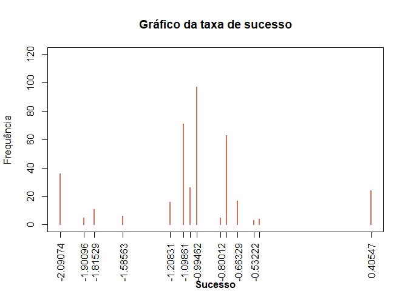

```r
plot(table(success),col="salmon3",main = "Gráfico da taxa de sucesso",xlab = "",ylab="Frequência",ylim=c(0,120),las=3)
mtext("Sucesso", 1 , line= 4,font = 2)
```

Através do gráfico a cima conclui-se que a taxa de sucesso que mais ocorre é uma taxa negativa, sendo esta -0.99462 com uma frequência de 97 casos. O que significa que a maior parte dos casos não tem sucesso, logo grande parte dos refugiados perderam o julgamento em tribunal.

### Caixa de bigodes da comparação a decisão do juiz com o sucesso

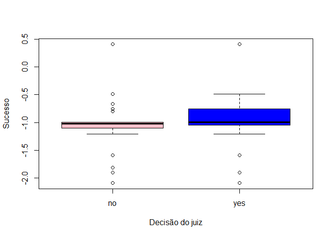

```r
boxplot(success~decision,ylab = "Sucesso",xlab = "Decisão do juiz",col=c("pink","blue"),names=levels(decision))
```

Através da comparação das caixas de bigodes a cima conclui-se que os refugiados provenientes de países com maior taxa de sucesso tem maior probabilidade da decisão do juiz erm tribunal ser “sim”.

### Gráfico de barras do numero de casos de cada juiz

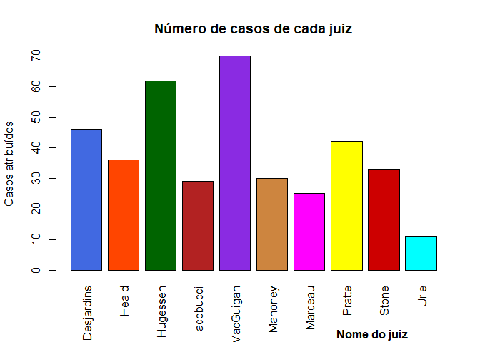

```r
barplot(table(judge),main="Número de casos de cada juiz",las=3,xlab="",ylab="Casos atribuídos",names.arg=c("Desjardins","Heald","Hugessen","Iacobucci","MacGuigan","Mahoney","Marceau","Pratte","Stone","Urie"),col=c("royalblue","orangered","darkgreen","firebrick","blueviolet","peru","magenta","yellow","red3","cyan"))
mtext("                                                                                   Nome do juiz", 1 , line= 4,font = 2)
```

Pelo gráfico de barras elaborado anterior deduz-se que o **MacGuigan** foi o juiz com maior número de casos atribuidos (70 casos) e por outro lado, o **Urie** foi o juiz com menor número de casos atribuidos (11 casos).

### Caixa de bigodes sucesso

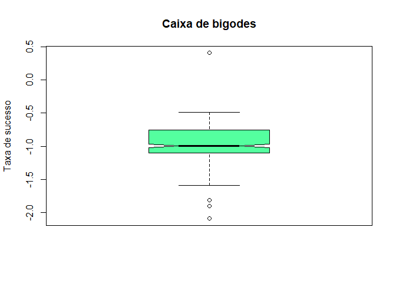

```r
boxplot(success,main="Caixa de bigodes",ylab="Taxa de sucesso",col="seagreen1",notch=TRUE)
```

A caixa de bigodes referente à variável “success” mostra-nos que o máximo da taxa de sucesso foi 0.40547 e o mínimo foi -2.09074. Além disso mais uma vez nota-se que maioria dos valores da taxa são negativos incluíndo o valor da média, sendo este -1.020439.

### Gráfico circular da decisão do juiz

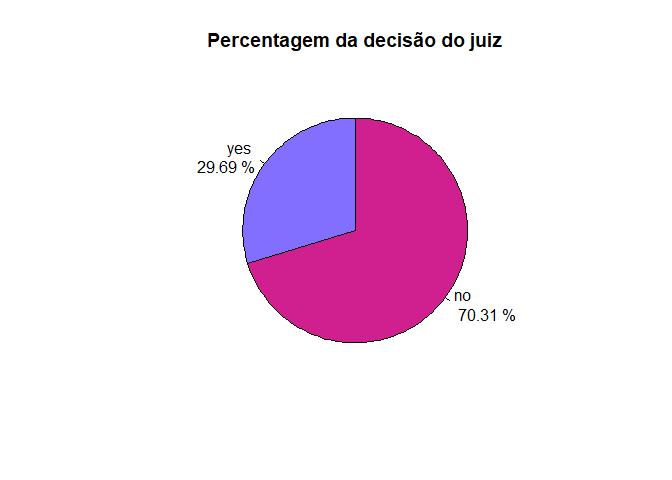

```r
pie(table(decision),clockwise = TRUE,main="Percentagem da decisão do juiz",col=c("violetred","slateblue1"),labels=paste(levels(decision),"\n",round(table(decision)/length(decision)*100,2),"%"))
```

Observando o gráfico circular referente à decisão do juiz entende-se que 70.31% destes tem uma resposta negativa e 29.69% uma resposta positiva. Ou seja, a maioria dos refugiados não teve uma resposta favorável para a reavaliação do seu caso.

### Gráfico para ver a influência do país origem na taxa de sucesso

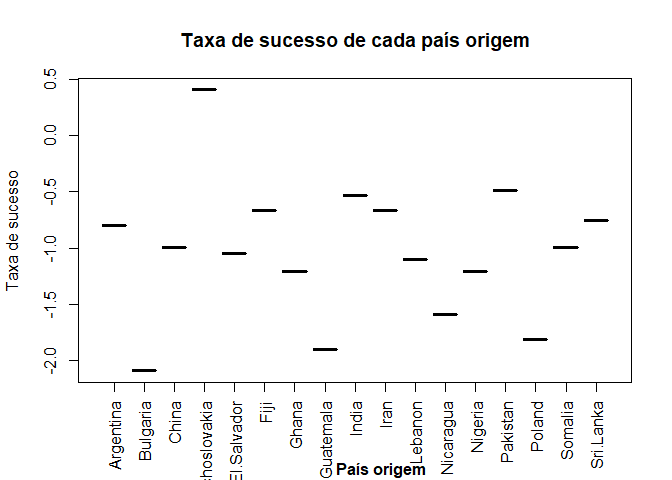

```r
plot(nation,success,las=3,pch=20,main="Taxa de sucesso de cada país origem",xlab="",ylab="Taxa de sucesso")
mtext("             País origem", 1 , line= 4,font = 2)
```

A representação gráfica vista anteriormente permite-nos perceber a taxa de sucesso referente ao país origem de refugiado. Sendo a taxa mais alta correspondente ao país Czechoslovakia com o valor de 0.40547.

### Gráfico de linhas do país origem

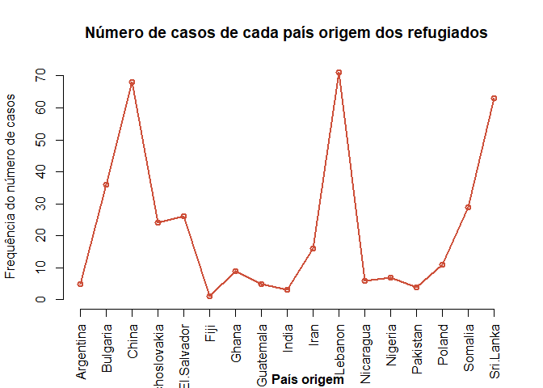

```r
plot(table(nation),type="o",main="Número de casos de cada país origem dos refugiados",ylab="Frequência do número de casos",xlab="",col="tomato3",las=3)
mtext("             País origem", 1 , line= 4,font = 2)
```

O gráfico anterior corresponde ao número de casos do país origem de cada refugiado. Tornando visivel a discrepância entre cada país. Observa-se que o país origem com mais casos de recurso **Lebanon** com valor igual a 71 e pelo contrário **Fiji** é o país origem com menos casos de recurso tendo apenas 1.

### Gráfico circular relativo à presença de júri

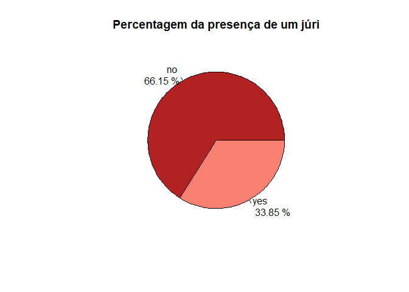

```r
pie(table(rater),main="Percentagem da presença de um júri",col=c("firebrick","salmon"),labels=paste(levels(rater),"\n",round(table(rater)/length(rater)*100,2),"%"))
```

O gráfico circular previamente apresentado mostra que há um valor significativo de casos (66.15%) em que não há presença de um júri.

### Gráfico de barras do número de casos julgados em cada cidade

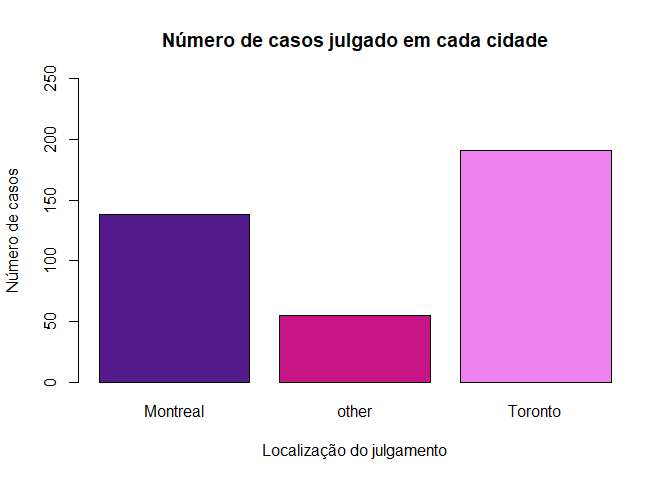

```r
barplot(table(location),main="Número de casos julgado em cada cidade",ylab="Número de casos",xlab="Localização do julgamento",col=c("purple4","mediumvioletred","violet"),ylim = c(0,250))
```

A representação gráfica diz-nos que **Toronto** foi a cidade Canadense com maior número de casos julgados(191 casos).

### Gráficos sobre a varíavel language

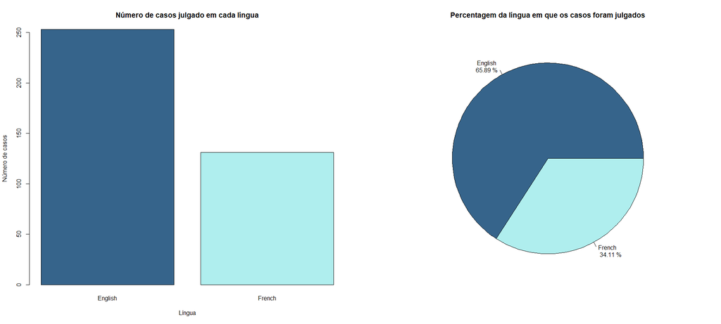

```r
par(mfrow=c(1,2))
barplot(table(language),main="Número de casos julgado em cada língua",ylab="Número de casos",xlab="Língua",col=c("steelblue4","paleturquoise"))
pie(table(language),main="Percentagem da língua em que os casos foram julgados",col=c("steelblue4","paleturquoise"),labels=paste(levels(language),"\n",round(table(language)/length(rater)*100,2),"%"))
```

### Gráfico de barras agrupado sobre distribuiçao dos casos por decisão e localização

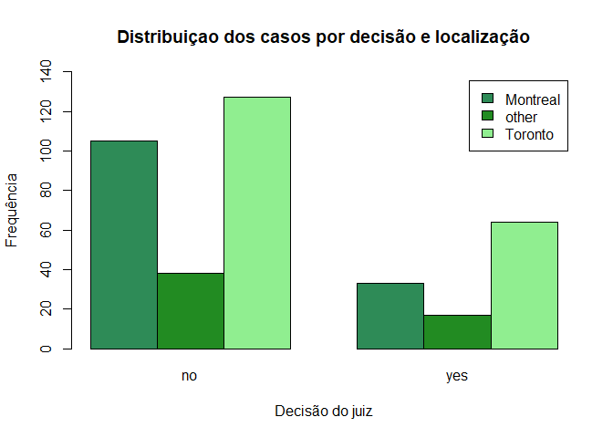

```r
counts <- table(location,decision)

barplot(counts, main="Distribuiçao dos casos por decisão e localização", xlab="Decisão do juiz",ylab="Frequência", col=c("seagreen","forestgreen","lightgreen"), beside = TRUE,legend.text=levels(location),ylim = c(0,140))
```

Tendo em conta a destribuição dos casos por decisão e localização mostrada, constata-mos que para cada cidade a decisão negativa é mais frequente do que a positiva.

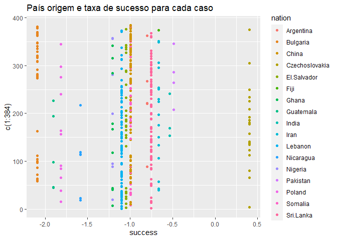

```r
library(ggplot2)
ggplot(basedados, aes(x=success,y=c(1:384),nation,color=nation))+
  geom_point()+ggtitle("País origem e taxa de sucesso para cada caso")
```

Para finalizar as representações gráficas, decidimos realizar um gráfico da biblioteca **ggplot2**. Neste é possível observar qual o país origem e a taxa de sucesso para cada caso, sendo que cada bolinha representa um caso( são 384 no seu total). Para facilitar a sua compreensão foi atribuída uma cor a cada país origem. As bolinhas mais à esquerda representam assim os casos com menor sucesso, que estão assinalados com a cor da **Bulgária**, sendo a Bulgária o país origem com um menor valor de taxa de sucesso. Por outro lado, os casos mais à direita representam os casos com maior sucesso, assinalados com a cor da **Czechoslovakia**, sendo este o país com um maior valor de taxa de sucesso.

# Inferência estatística

### Testes de normalidade

Iremos usar a biblioteca **nortest** para testar a normalidade da variável “success”. Para tal iremos utilizar O teste de Kolmogorov-Smirnov, teste de Shapiro-Wilk e o teste de Lilliefors.

```r
library(nortest)
shapiro.test(success)
```

```
##
##  Shapiro-Wilk normality test
##
## data:  success
## W = 0.83233, p-value < 2.2e-16
```

```r
ks.test(x=success,"pnorm",mean(success,na.rm = T),sd(success,na.rm = T))
```

```
##
##  One-sample Kolmogorov-Smirnov test
##
## data:  success
## D = 0.24997, p-value < 2.2e-16
## alternative hypothesis: two-sided
```

```r
lillie.test(success)
```

```
##
##  Lilliefors (Kolmogorov-Smirnov) normality test
##
## data:  success
## D = 0.24997, p-value < 2.2e-16
```

Considerando um nível e significância de 5%,e considerando os 3 testes realizados anteriormente, rejeitamos Ho (hipótese nula) e concluímos assim que os dados não são provenientes de uma populacão normal (pois p-value < 0.05).

# Conclusão

Para a execução deste projeto e tendo em conta o seu contexto excecional da ocorrência de uma pandemia, fomos obrigadas a realizar o mesmo à distância, dificultando a comunicação e a exploração em conjunto das ferramentas e programas apresentados, bem como a discussão do trabalho em si. Assim, como solução para tal situação, trabalhamos na realização do projeto em conjunto pelo menos uma vez por semana, utilizando as redes sociais para vídeochamada. Nestes momentos semanais, trocamos ideias sobre o projeto e decidíamos qual o próximo passo a fazer, escrevendo as duas o código do projeto, de forma a ambos os elementos do grupo poderem acompanhar a evolução do trabalho.Desta forma, a realização deste trabalho foi realizada em conjunto por todos os membros do grupo, desde a pesquisa e recolha de informação sobre o tema abordado e a respetiva base, até à realização em si do Script Rmarkdown, passando por uma pesquisa de como utilizar este e qual a estrutura do documento html originado, bem como a tentativa de descoberta de como melhorar o design do mesmo de forma a torná-lo mais apelativo. Reforçamos assim a existência de vários obstáculos que foram ultrapassados com sucesso e que culminaram para uma maior aprendizagem. Em adição achamos que este trabalho de projeto contribuiu para o desenvolvimento das nossas capacidades de pesquisa, de utilização do software R (Rstudio) e respetiva realização de gráficos, criatividade e sobretudo no desenvolvimento da aplicação da matéria lecionada na UC de Laboratórios de Estatística II. Com este trabalho foi possível estudar de que forma o país origem,localização ou por exemplo a linguagem em que é feito o julgamento influencia a decisão do juíz atribuído para o respetivo caso, transparecendo a diferença de oportunidades e parcialidades existentes na sociedade.Também fomos capazes de apurar várias disparidades nas taxas de sucesso referentes a cada país. Após a realização deste trabalho, podemos afirmar que enriquecemos o nosso conhecimento. Além disso, o trabalho dinamizado permitiu também o desenvolvimento do estímulo do raciocínio, a capacidade de trabalho em grupo, a responsabilidade, criatividade e autonomia. Em suma, consideramos que os objetivos deste foram alcançados e corresponderam às expectativas do professor responsável pela unidade curricular e do grupo nomeadamente por ter potenciado espaços/ momentos de partilha, aprendizagem e reflexão conjunta no contexto académico, no desenvolvimento de competências e atitudes em termos de partilha e colaboração e na consciencialização da importância da imparcialidade quando se trata do julgamento de casos em tribunal e consequências do desequilíbrio desta. A partir da voz do professor foi também possível recolher informações relevantes que permitissem uma melhor compreensão das oportunidades de aprendizagem no contexto de trabalho.

# Webgrafia/Documentação consultada

https://vincentarelbundock.github.io/Rdatasets/doc/carData/Greene.html

http://cursos.leg.ufpr.br/prr/capDocDin.html

https://www.statmethods.net/graphs/pie.html

https://www.youtube.com/watch?v=4qA9JepiI4M&t=505s

https://rpubs.com/brandonkopp/RMarkdown

https://www.youtube.com/watch?v=tKUufzpoHDE&t=278s

https://rpubs.com/jovial/r

https://www.youtube.com/watch?v=ONrGJF_8onw

https://www.it-swarm.dev/pt/r/r-markdown-alterando-o-tamanho-e-o-tipo-da-fonte-na-saida-html/1052405929/

https://bookdown.org/yihui/rmarkdown/html-document.html

https://stackoverflow.com/questions/10560786/changing-color-of-twitter-bootstrap-nav-pills/30324279#30324279

https://stackoverflow.com/questions/42546001/how-to-change-colors-and-attributes-of-table-of-contents-in-r-markdown-html-docu

https://www.statmethods.net/advgraphs/axes.html